# Stat 21 Week 5 Worksheet

Monday, Feb 14, 2022

This worksheet is to be completed in class as a group. Take a minute to have everyone introduce themselves and then choose who will play the role of **recorder** and **reporter**. The recorder is responsible for completing this worksheet and emailing the .Rmd file to your professor with the subject **“Stat 21: Week 5 Worksheet”**. Make sure everyone’s name is included at the top of this document! The reporter is responsible for taking note of your answers and any questions that come up to share them with Prof. Suzy or the Muse when they stop by to check in on your group. Other groups members are responsible for keeping the discussion on-task and providing possible solutions or sharing questions with the group.

For this assignment, I suggest that you choose the recorder to be whoever last ate cereal for breakfast and choose the reporter to be whoever hasn’t had cereal for breakfast in the longest time (or ever).

# Step 1: Choose

Create a data frame for PalmBeach.

```r
data("PalmBeach")
names(PalmBeach)
```

```
## [1] "County"   "Buchanan" "Bush"
```

# Step 2: Fit

Fit a model to predict Buchanan votes using Bush votes.

```r
regall <- lm(Buchanan~Bush, data=PalmBeach)
regall %>% summary
```

```
##
## Call:
## lm(formula = Buchanan ~ Bush, data = PalmBeach)
##
## Residuals:
##     Min      1Q  Median      3Q     Max
## -907.50  -46.10  -29.19   12.26 2610.19
##
## Coefficients:
##              Estimate Std. Error t value Pr(>|t|)
## (Intercept) 4.529e+01  5.448e+01   0.831    0.409
## Bush        4.917e-03  7.644e-04   6.432 1.73e-08 ***
## ---
## Signif. codes:  0 '***' 0.001 '**' 0.01 '*' 0.05 '.' 0.1 ' ' 1
##
## Residual standard error: 353.9 on 65 degrees of freedom
## Multiple R-squared:  0.3889, Adjusted R-squared:  0.3795
## F-statistic: 41.37 on 1 and 65 DF,  p-value: 1.727e-08
```

Plot all data for the 2000 presidential election totals in Florida counties

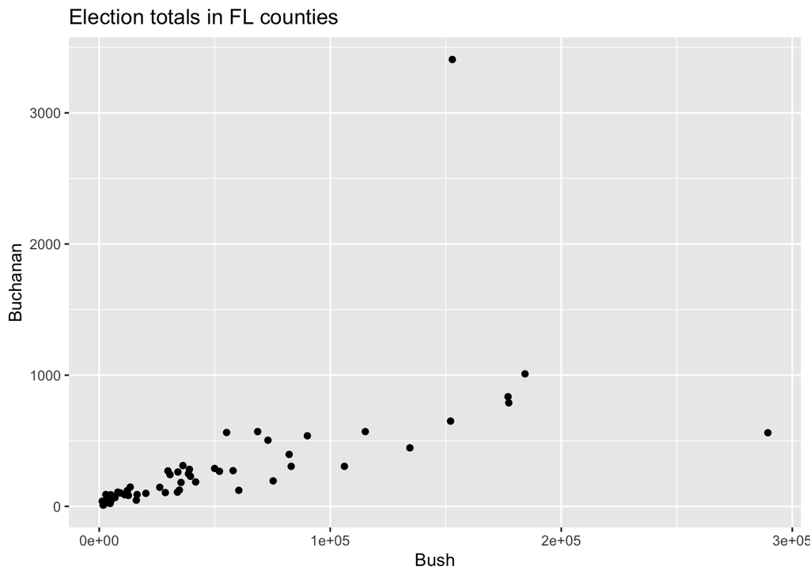

```r
ggplot(PalmBeach, aes(x=Bush, y=Buchanan)) +
  geom_point() +
  labs(title="Election totals in FL counties", x="Bush", y="Buchanan")
```